# ashishsa_hw5_p1

We are going to use User Based Collaborative Filtering to filter the Users in the Movie Lense Data which is available in the Recommender Package.

```r
library(ggplot2)
library(pander)
library(caret)
library(recommenderlab)
data("MovieLense")
d <- MovieLense
```

We now check the number of rows in the data.

```r
nrow(d)
```

```
## [1] 943
```

We now check the number of columns in the data.

```r
ncol(d)
```

```
## [1] 1664
```

We now take a look at the list of the names of the Movies in the data.

```r
v1 <- as.vector(names(colCounts(MovieLense)))
head(v1)
```

```
## [1] "Toy Story (1995)"
## [2] "GoldenEye (1995)"
## [3] "Four Rooms (1995)"
## [4] "Get Shorty (1995)"
## [5] "Copycat (1995)"
## [6] "Shanghai Triad (Yao a yao yao dao waipo qiao) (1995)"
```

We now make a list and frequency of the ratings to analyze the number of ratings. Since there are 1664 movies and 943 users there should be a maximum of 1,569,152 ratings.

```r
ratings <- as.vector(MovieLense@data)
table(ratings)
```

```
## ratings
##       0       1       2       3       4       5
## 1469760    6059   11307   27002   33947   21077
```

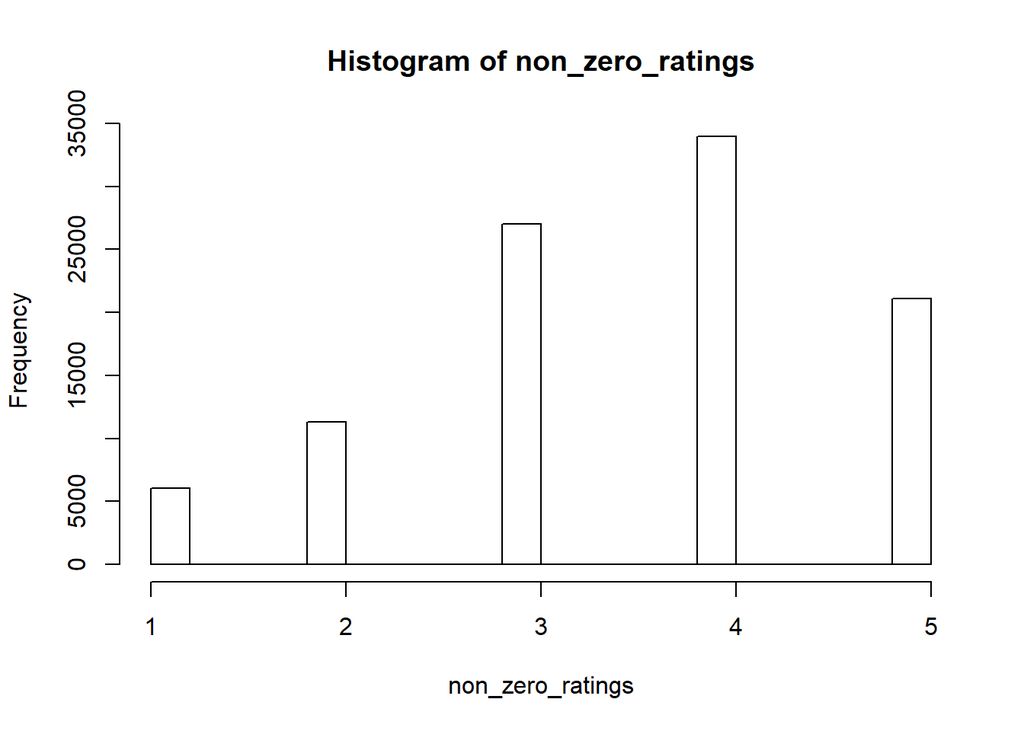

```r
non_zero_ratings <- ratings[ratings!=0]
hist(non_zero_ratings)
```

We observe that most of the users have rated the movie between 3 and 5. With the maximum users giving a rating of 4 to the movie.

We now create a Ratings Matrix from the MovieLense data by the following way.

```r
R <- as(MovieLense@data, "realRatingMatrix")
l <- (getRatingMatrix(R)[1:10, 1:10])
l
```

```
## 10 x 10 sparse Matrix of class "dgCMatrix"
```

```
##    [[ suppressing 10 column names 'Toy Story (1995)', 'GoldenEye (1995)', 'Four Rooms (1995)' ... ]]
```

```
##
## 1  5 3 4 3 3 5 4 1 5 3
## 2  4 . . . . . . . . 2
## 3  . . . . . . . . . .
## 4  . . . . . . . . . .
## 5  4 3 . . . . . . . .
## 6  4 . . . . . 2 4 4 .
## 7  . . . 5 . . 5 5 5 4
## 8  . . . . . . 3 . . .
## 9  . . . . . 5 4 . . .
## 10 4 . . 4 . . 4 . 4 .
```

We now Normalize the Rating to remove the user bias. Since every user might overrateor underrate a movie based on his/her preferance.

```r
R_Normalize <- normalize(R)
getRatingMatrix(R_Normalize)[1:10,1:10]
```

```
## 10 x 10 sparse Matrix of class "dgCMatrix"
```

```
##    [[ suppressing 10 column names 'Toy Story (1995)', 'GoldenEye (1995)', 'Four Rooms (1995)' ... ]]
```

```
##
## 1   1.3948339 -0.6051661 0.3948339 -0.6051661 -0.6051661 1.3948339  0.3948339
## 2   0.2950820  .         .          .          .         .          .
## 3   .          .         .          .          .         .          .
## 4   .          .         .          .          .         .          .
## 5   1.1257143  0.1257143 .          .          .         .          .
## 6   0.3605769  .         .          .          .         .         -1.6394231
## 7   .          .         .          1.0350000  .         .          1.0350000
## 8   .          .         .          .          .         .         -0.7966102
## 9   .          .         .          .          .         0.7272727 -0.2727273
## 10 -0.2065217  .         .         -0.2065217  .         .         -0.2065217
##
## 1  -2.6051661  1.3948339 -0.6051661
## 2   .          .         -1.7049180
## 3   .          .          .
## 4   .          .          .
## 5   .          .          .
## 6   0.3605769  0.3605769  .
## 7   1.0350000  1.0350000  0.0350000
## 8   .          .          .
## 9   .          .          .
## 10  .         -0.2065217  .
```

We now plot the image to observe the Un-Normalized ratings data.

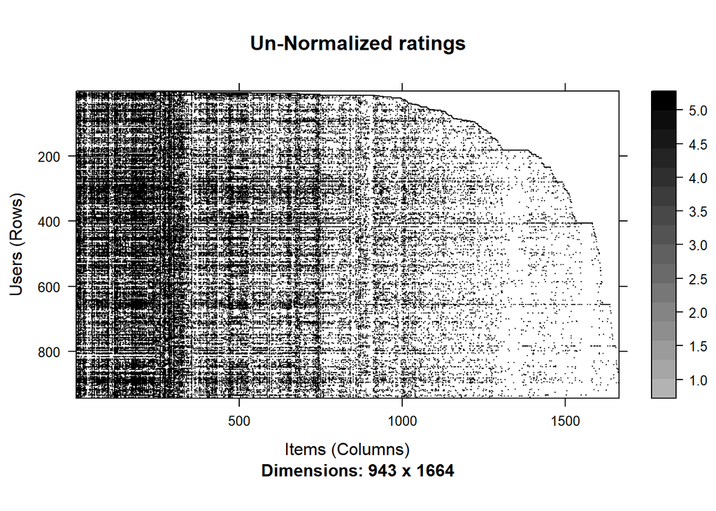

```r
image(R, main = "Un-Normalized ratings")
```

The user ratings lie between 1-5. We now plot the image to observe the Normalized ratings data.

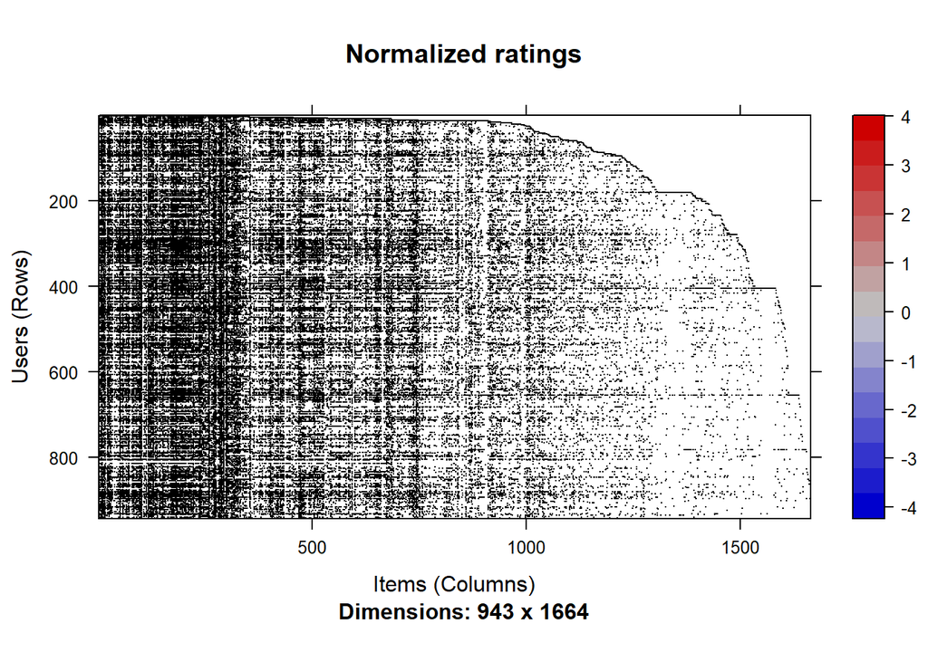

```r
image(R_Normalize, main = "Normalized ratings")
```

After Normalizing the ratings now lie between -4 to 4. This is done to remove any Bias in the data. We now plot the histogram to observe the Un-Normalized ratings data.

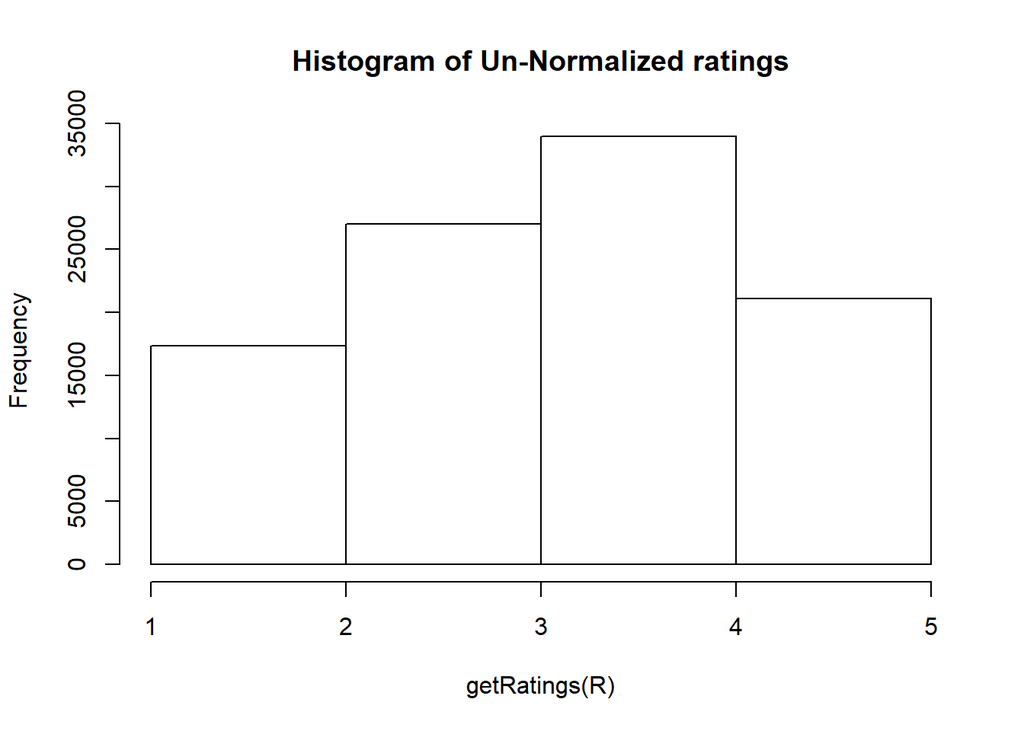

```r
hist(getRatings(R), breaks = 5, main = "Histogram of Un-Normalized ratings")
```

We now plot the histogram to observe the Normalized ratings data.

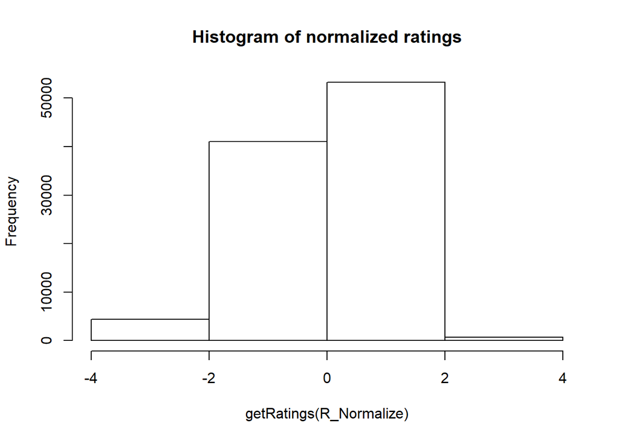

```r
hist(getRatings(R_Normalize), breaks = 5, main = "Histogram of normalized ratings")
```

After Normalizing the data the Ratings that existed between 0-5 now lie in the range -4 to +4. Mostof the ratings are in the range -2 to +2.

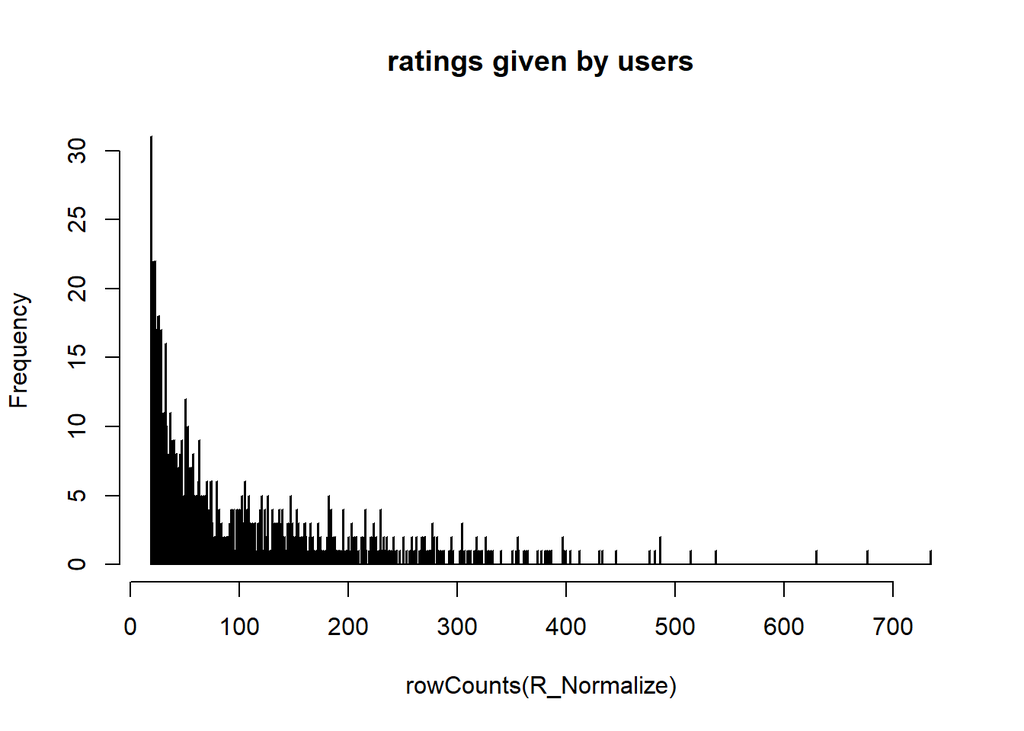

```r
hist(rowCounts(R_Normalize), breaks = 1664, main = "ratings given by users")
```

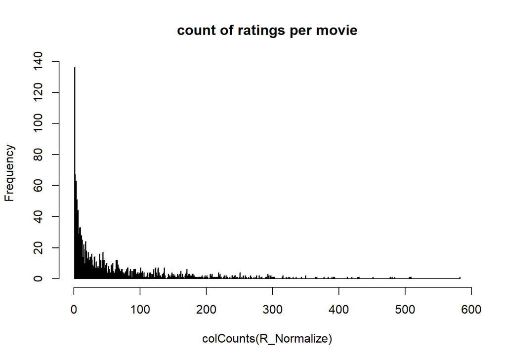

```r
hist(colCounts(R_Normalize), breaks = 934, main = "count of ratings per movie")
```

We now get the Movie Lense data Metadata which divides the movies into various Genres.

```r
moviemeta <- MovieLenseMeta
head(moviemeta)
```

```
##                                                  title year
## 1                                     Toy Story (1995) 1995
## 2                                     GoldenEye (1995) 1995
## 3                                    Four Rooms (1995) 1995
## 4                                    Get Shorty (1995) 1995
## 5                                       Copycat (1995) 1995
## 6 Shanghai Triad (Yao a yao yao dao waipo qiao) (1995) 1995
##                                                            url unknown Action
## 1        http://us.imdb.com/M/title-exact?Toy%20Story%20(1995)       0      0
## 2          http://us.imdb.com/M/title-exact?GoldenEye%20(1995)       0      1
## 3       http://us.imdb.com/M/title-exact?Four%20Rooms%20(1995)       0      0
## 4       http://us.imdb.com/M/title-exact?Get%20Shorty%20(1995)       0      1
## 5            http://us.imdb.com/M/title-exact?Copycat%20(1995)       0      0
## 6 http://us.imdb.com/Title?Yao+a+yao+yao+dao+waipo+qiao+(1995)       0      0
##   Adventure Animation Children's Comedy Crime Documentary Drama Fantasy
## 1         0         1          1      1     0           0     0       0
## 2         1         0          0      0     0           0     0       0
## 3         0         0          0      0     0           0     0       0
## 4         0         0          0      1     0           0     1       0
## 5         0         0          0      0     1           0     1       0
## 6         0         0          0      0     0           0     1       0
##   Film-Noir Horror Musical Mystery Romance Sci-Fi Thriller War Western
## 1         0      0       0       0       0      0        0   0       0
## 2         0      0       0       0       0      0        1   0       0
## 3         0      0       0       0       0      0        1   0       0
## 4         0      0       0       0       0      0        0   0       0
## 5         0      0       0       0       0      0        1   0       0
## 6         0      0       0       0       0      0        0   0       0
```

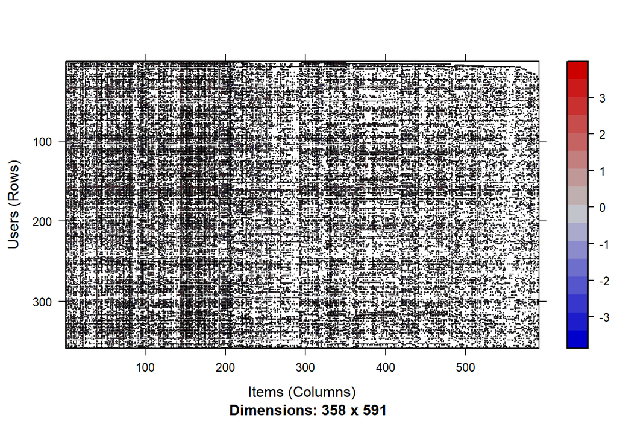

```r
v2 <- R_Normalize[rowCounts(R_Normalize) > 100, colCounts(R_Normalize) > 50]

image(v2)
```

From the image we can observe that most of the users have rated the movies. Unlike the Entire Data which showed a huge Empty space attributing to users with very low or no ratings.

We now divide the dataset into train and test datasets

```r
R_denormalize <- denormalize(R_Normalize)
which_set <- sample(x = 1:5, size = nrow(R_denormalize), replace = TRUE)
for(i_model in 1:5)
{
  which_train <- which_set == i_model
  data_test <- R_denormalize[which_train, ]
  data_train <- R_denormalize[!which_train, ]
}
```

```r
recommender_popularity <- Recommender(data_train, method = "UBCF",parameter = list(method = "Cosine"))
recommender_popularity
```

```
## Recommender of type 'UBCF' for 'realRatingMatrix'
## learned using 728 users.
```

We now make a list of top 20 movies to most recommended users

```r
number_recommendation <- 20
recommender_prediction1 <- predict(recommender_popularity,newdata=data_test,n=number_recommendation)
recommender_prediction1
```

```
## Recommendations as 'topNList' with n = 20 for 215 users.
```

```r
recdfub <- data.frame(user = sort(rep(1:length(recommender_prediction1@items), recommender_prediction1@n)),
    rating = unlist(recommender_prediction1@ratings), index = unlist(recommender_prediction1@items))
recdfub
```

```
##      user   rating index
## 1       1 4.699023    98
## 2       1 4.545175   299
## 3       1 4.519447   234
## 4       1 4.514628   331
## 5       1 4.452180   270
## 6       1 4.447536   316
## 7       1 4.445295   305
## 8       1 4.430747    56
## 9       1 4.429521     1
## 10      1 4.425167    64
## 11      1 4.422069   345
## 12      1 4.413347   216
## 13      1 4.411742   432
## 14      1 4.406930  1007
```

[output cut: 4286 more lines]

The User Based Recommendation System uses the data available in the Train and Test Dataset to recommend the ratings of the movie not seen by using the top nearest users and recommend 20 movies and rate it by using the ratings of the nearest users.